# Data Analysis Exercise

Mina Ekramnia

11/19/2019

### Intoduction

According to United Nation’s Indicators of Sustainable Development, Life expectancy at birth is defined as the average number of years that a newborn could expect to live if he or she were to pass through life subject to the age-specific mortality rates of a given period. Life expectancy is a measure that is often used to gauge the overall health of a community. Here, we are going to analyze the trend of life extency at birth, between the years of 1960-2017, and demonstrate some highlights.

### Retrieving the Data from the API

Using World Bank API, I derived the data for the Life Expectancy at birth (in years) for all the countries in the WDI starting 1960. Since R does not work well with JSON file format from the APIs, I download the files as CSV and then read it.

```r
#setting general working directory
cd <- getwd()
temp <- tempfile()
#temp <- filepath
download.file("https://api.worldbank.org/v2/en/country/all/indicator/SP.DYN.LE00.IN?downloadformat=csv&per_page=20000&source=2",temp)
# unzipping the downloaded file into an exported directory
unzip(temp, exdir = "WBDATA")

#Reading the data
filepath <- paste(cd,"/","WBDATA", sep="")
files <-list.files(filepath)
#Life Expectancy data
df1 <-read.csv(file = paste(filepath,"/",files[1], sep=""), header=T, skip=4)
#Metadata
df2 <- read.csv(file = paste(filepath,"/",files[2], sep=""), header=TRUE, sep=",")
```

### Preprocessing the Data

In order to be able to use the data, I did some preprocess on the data. First, merged the Life Expectancy dataset with the meta data one so that we have information about each country’s region and income level. Then transformed the result in to long format so that all the years are in one column. Then removed then NAs and rename the columns so that it will be easier to use.

```r
# merge two data frames by ID
total <- merge(df1,df2,by="Country.Code")

total_long <-melt(total, id.vars=c("Country.Code", "Country.Name", "Indicator.Name", "Indicator.Code","Region", "IncomeGroup", "SpecialNotes","TableName", "X.x","X.y"))

#Dropping NAs for Life Expectancy value
total_long <-drop_na(total_long,value)
total_long <-drop_na(total_long,Region)

#renaming columns
names(total_long)[names(total_long) == "value"] <- "LifeExp"
names(total_long)[names(total_long) == "variable"] <- "Year"

#renaming years in each raw cause when R read them has added an X before the numbers
total_long$Year <- substring(total_long$Year,2)
```

Now that we have our data cleaned, we are ready to do some exploration and analysis.  
First we plot Life Expectancy by year for each country group by each region. As we see they all have similar increasing trends between 1960-2017.

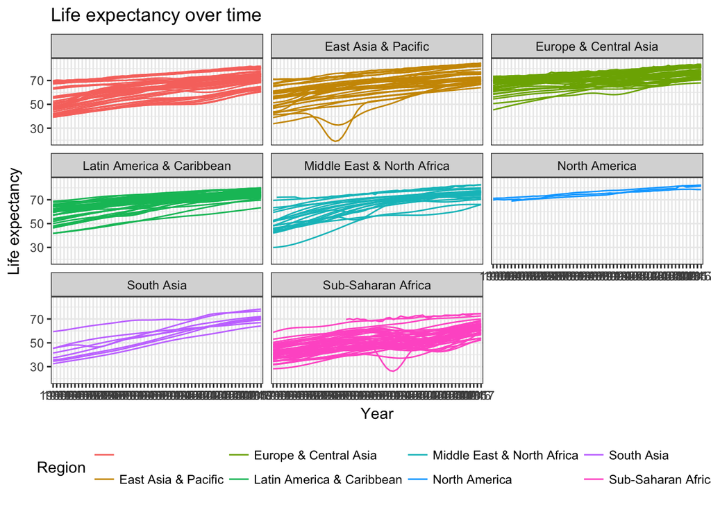

```r
#Group Plot for each Region
ggplot(data = total_long,
        aes(x = Year, y = LifeExp,
            group = Country.Name,
            color = Region)) +
   geom_line() +
   xlab("Year") +
   ylab("Life expectancy") +
   ggtitle("Life expectancy over time") +
   theme_bw() +
   facet_wrap(~ Region) +
   theme(legend.position = "bottom")
```

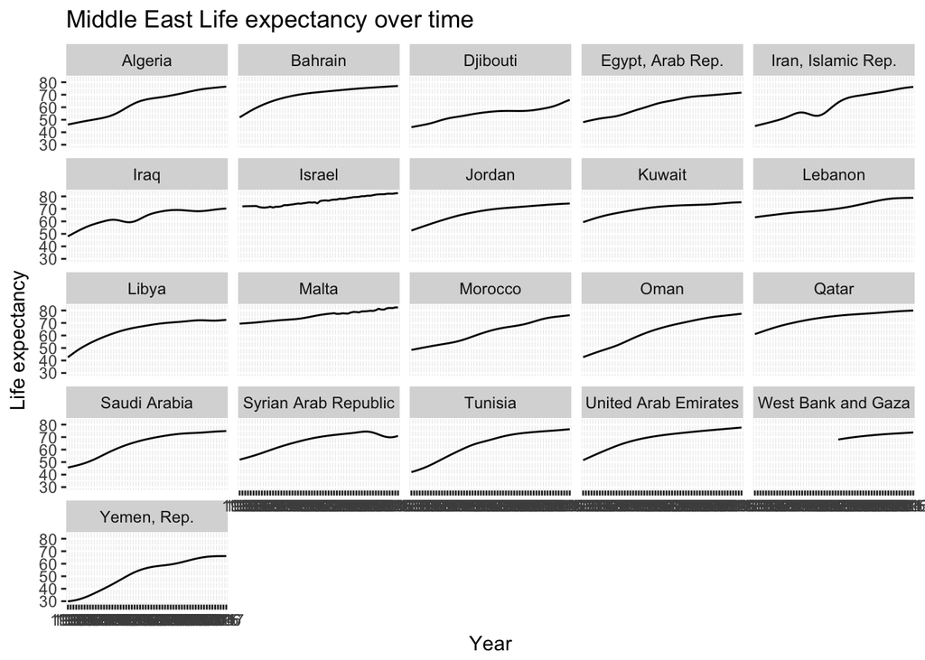

Looking closely to the plots above, we see a significant drop in Iran’s life expectancy that we wanted to investigate. When we plot the results for Iran, we see this decreasing rate starts from 1977, reach a minimum and then increase to a steady rate until around 1992. This is exactly around the period that the protests before 1979 revolution start and followed by the war with Iraq until 1988. In order to strenghten our hypothesis, we will take a look at Iraq’s Life Expectancy trend during that period.Then we calculate the correlation between Iran and Iraq trend. If the drop in their trend is due to the mutual war between them, there should be a higher correlation than a correlation with a random country like China. Below we will see the results.

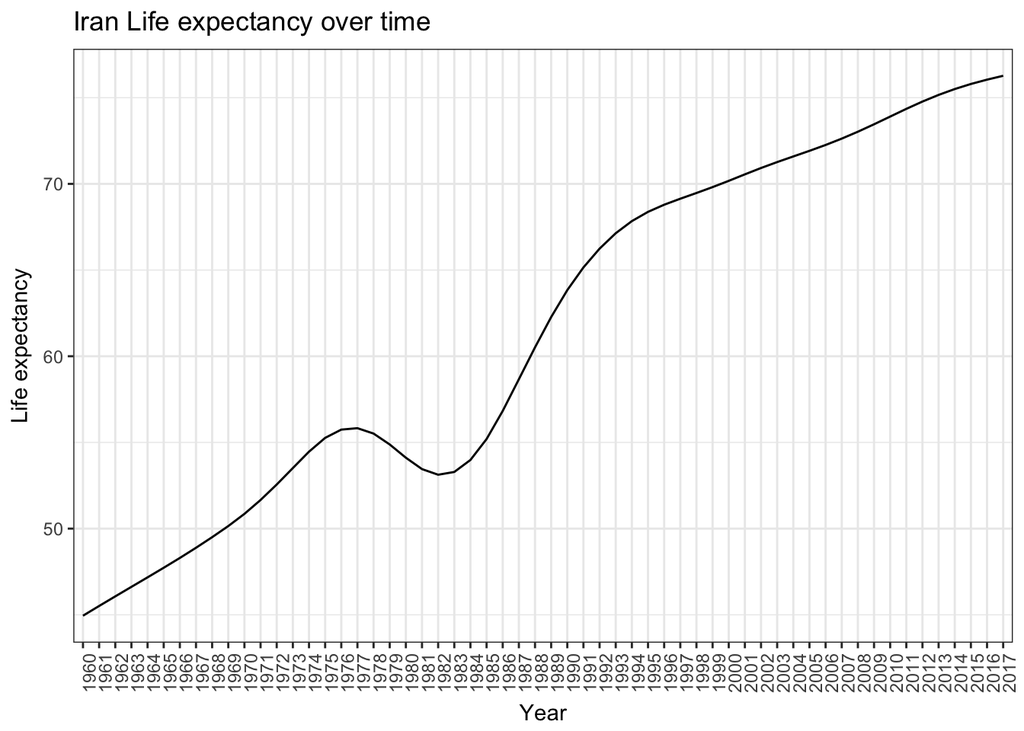

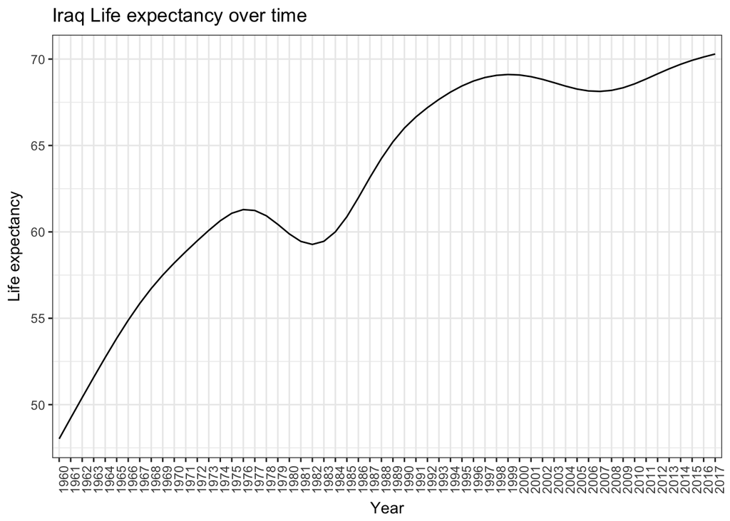

```
##
##  Pearson's product-moment correlation
##
## data:  Iran$LifeExp and Iraq$LifeExp
## t = 25.409, df = 56, p-value < 2.2e-16
## alternative hypothesis: true correlation is not equal to 0
## 95 percent confidence interval:
##  0.9318534 0.9757838
## sample estimates:
##      cor
## 0.959261
```

```
##
##  Pearson's product-moment correlation
##
## data:  Iran$LifeExp and China$LifeExp
## t = 13.731, df = 56, p-value < 2.2e-16
## alternative hypothesis: true correlation is not equal to 0
## 95 percent confidence interval:
##  0.8015683 0.9262816
## sample estimates:
##       cor
## 0.8780675
```

### Correlation Analysis

As we expected, there is a significantly high correlation (95.92%, p-value < 2.2e-16) between Iran and Iraq trend of life-expectancy in compare to correlation between Iran and China (87.8%, p-value < 2.2e-16) which demonstrates that they had similar underlying social environmental situation such as war which led to increasing infant mortality rate and lack of access to appropriate healthcare system. Life expectancy at birth is strongly influenced by infant and child mortality; Gradually, improvements in health and welfare increase life expectancy as the plots above demonstrate.

### Other Possible Analysis

It is also worth to plot the cross correlation between all the countries trends and see if countries with similar income level have high correlation rate with each other. Unfortunately, due to the limited time and current political situations in home country, I could not continue my farther analysis.